# Machine Learning 2019: Tree-Based Methods

## The Boston Housing Dataset

506 Observations, 14 variables Response Variable: medv (median value of owner-occupied homes for each suburb)

```r
data("Boston")
boston = Boston
head(Boston)
```

|  | crim | zn | indus | chas | nox | rm | age | dis | rad | tax | ptratio | black | lstat | medv |
| --- | --- | --- | --- | --- | --- | --- | --- | --- | --- | --- | --- | --- | --- | --- |
| 1 | 0.00632 | 18 | 2.31 | 0 | 0.538 | 6.575 | 65.2 | 4.0900 | 1 | 296 | 15.3 | 396.90 | 4.98 | 24.0 |
| 2 | 0.02731 | 0 | 7.07 | 0 | 0.469 | 6.421 | 78.9 | 4.9671 | 2 | 242 | 17.8 | 396.90 | 9.14 | 21.6 |
| 3 | 0.02729 | 0 | 7.07 | 0 | 0.469 | 7.185 | 61.1 | 4.9671 | 2 | 242 | 17.8 | 392.83 | 4.03 | 34.7 |
| 4 | 0.03237 | 0 | 2.18 | 0 | 0.458 | 6.998 | 45.8 | 6.0622 | 3 | 222 | 18.7 | 394.63 | 2.94 | 33.4 |
| 5 | 0.06905 | 0 | 2.18 | 0 | 0.458 | 7.147 | 54.2 | 6.0622 | 3 | 222 | 18.7 | 396.90 | 5.33 | 36.2 |
| 6 | 0.02985 | 0 | 2.18 | 0 | 0.458 | 6.430 | 58.7 | 6.0622 | 3 | 222 | 18.7 | 394.12 | 5.21 | 28.7 |

## Bagging: Random Forest

Bagging involves creating multiple copies of the original training dataset using the bootstrap, fitting a separate decision tree to each copy, and then combining all of the trees in order to create a single predictive model. Each tree is built on a bootstrapped dataset, independent of the other trees.

Random Forest: Each time a split in a tree is considered, a random sample of m predictors is chosen as split candidates from the full set of p predictors. The split is allowed to use only one of those m predictors.

```r
#set seed for reproducibility
set.seed(29)

#split into train and test sets (300 and 206 respectively)
train = sample(1:nrow(boston), 300)

#fit training subset of data to model
rf.boston = randomForest(medv~., data = boston, subset = train)
rf.boston
```

```
##
## Call:
##  randomForest(formula = medv ~ ., data = boston, subset = train)
##                Type of random forest: regression
##                      Number of trees: 500
## No. of variables tried at each split: 4
##
##           Mean of squared residuals: 12.86824
##                     % Var explained: 83.94
```

[figure not shown]

```r
#summary of rf.boston gives information about the number of trees, the mean squared residuals (MSR), and the percentage of variance explained

#No. of variables tried at each split: 4
#Each time the tree comes to split a node, 4 variables would be selected at random, then the split would be confined to 1 of those 4 variables.

##Lets try a range of mtry (number of variables selected at random at each split)

oob.err = double(13)
test.err = double(13)

#In a loop of mtry from 1 to 13, you first fit the randomForest to the train dataset
for(mtry in 1:13){
  fit = randomForest(medv~., data = boston, subset=train, mtry=mtry, ntree = 350)
  oob.err[mtry] = fit$mse[350] ##extract Mean-squared-error
  pred = predict(fit, boston[-train,]) #predict on test dataset
  test.err[mtry] = with(boston[-train,], mean( (medv-pred)^2 )) #compute test error
}

#Visualize
matplot(1:mtry, cbind(test.err, oob.err), pch = 23, col = c("red", "blue"), type = "b", ylab="Mean Squared Error")
legend("topright", legend = c("OOB", "Test"), pch = 23, col = c("red", "blue"))
```

## Boosting

Boosting is another approach to improve the predictions resulting from a decision tree. Trees are grown sequentially: each tree is grown using information from previously grown trees. Each tree is fitted on a modified version of the original dataset.

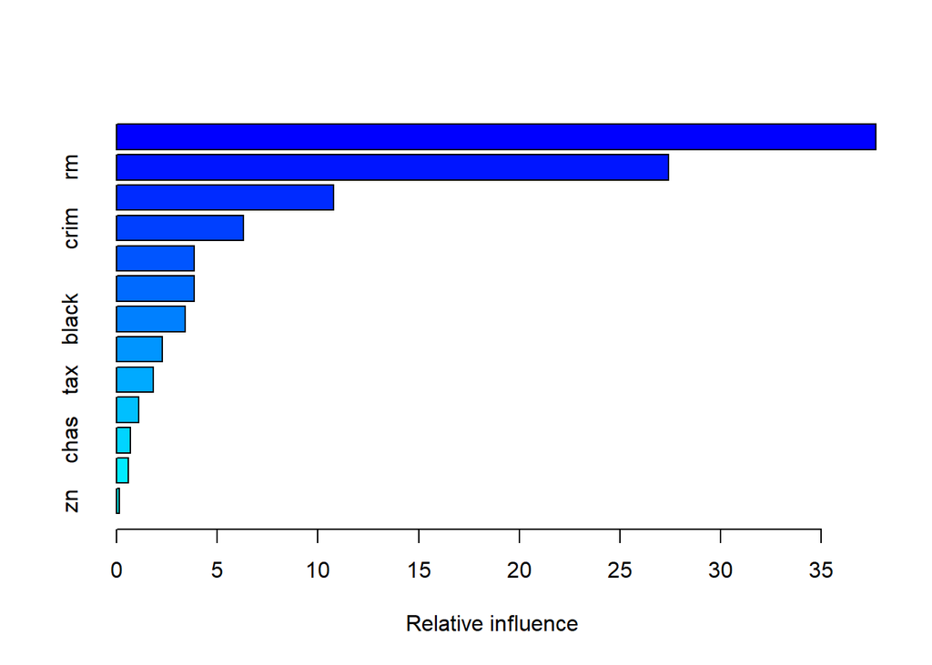

|  | var | rel.inf |
| --- | --- | --- |
| lstat | lstat | 37.6982917 |
| rm | rm | 27.4231506 |
| dis | dis | 10.7870570 |
| crim | crim | 6.3190588 |
| nox | nox | 3.8741970 |
| age | age | 3.8660387 |
| black | black | 3.4055088 |
| ptratio | ptratio | 2.2861013 |
| tax | tax | 1.8341376 |
| indus | indus | 1.0918593 |

[output cut: 3 more lines]

```r
#Gradient Boosting Model
boost.boston = gbm(medv~., data = boston[train,], distribution = "gaussian", n.trees = 10000, shrinkage = 0.01, interaction.depth = 4)

#Variable Importance Plot
summary(boost.boston)
```

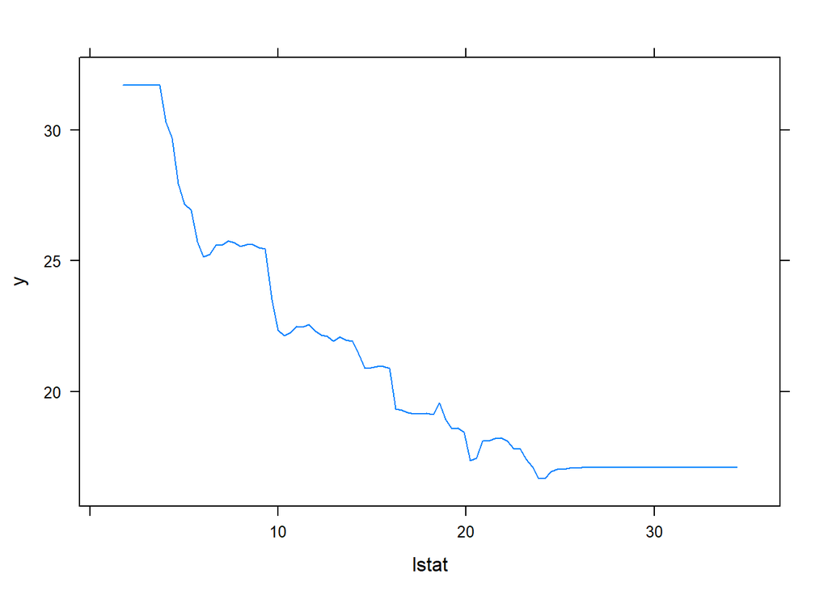

```r
#Visualize important variables of interest
plot(boost.boston,i="lstat")
```

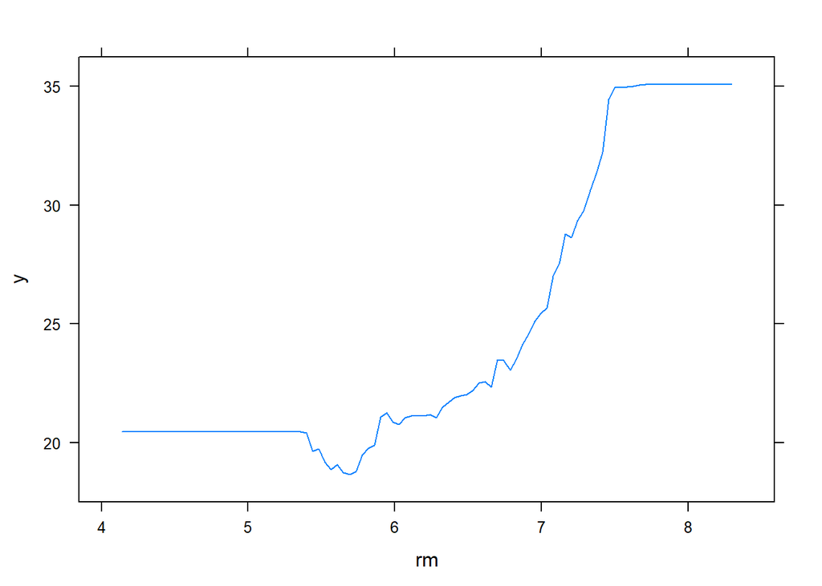

```r
plot(boost.boston,i="rm")
```

```r
#Predict on test set
n.trees = seq(from = 100, to = 10000, by = 100)
predmat = predict(boost.boston, newdata = boston[-train,], n.trees = n.trees)
dim(predmat)
```

```
## [1] 206 100
```

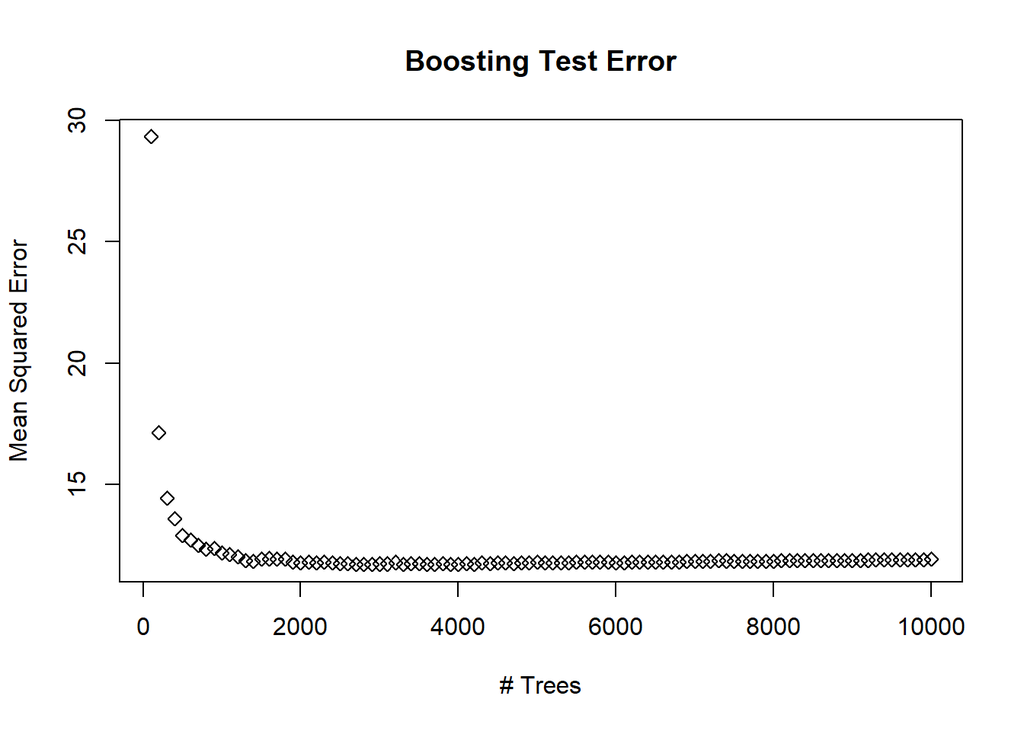

```r
#Visualize Boosting Error Plot
boost.err = with(boston[-train,], apply( (predmat - medv)^2, 2, mean) )
plot(n.trees, boost.err, pch = 23, ylab = "Mean Squared Error", xlab = "# Trees", main = "Boosting Test Error")
abline(h = min(test.err), col = "red")
```

## Homework

1. Attempt a regression tree-based method (not covered in this tutorial) on a reasonable dataset of your choice. Explain the results.

```r
# Regression Tree (Conditional Inference method)

# Conditional Inference Trees use a significance test procedure to select variables at each split. This overcomes a variable selection bias in the algorithms used in the traditional CART-based trees. Traditional approaches tend to select variables that have many possible splits or many missing values.

# set seed to make results reproducible
set.seed(29)

# split data into train and test subset (300 and 206 respectively)
train = sample(1:nrow(boston), 300)

# MODEL

# fit train subset of data to model
ctree.fit <- ctree(medv ~ .,
                   data = boston,
                   subset = train,
                   control = ctree_control(maxdepth = Inf))
# 'maxdepth = Inf' means no restrictions are applied to tree size

# EVALUATION OF MODEL

# display the details of the tree
print(ctree.fit)
```

```
##
## Model formula:
## medv ~ crim + zn + indus + chas + nox + rm + age + dis + rad +
##     tax + ptratio + black + lstat
##
## Fitted party:
## [1] root
## |   [2] lstat <= 9.62
## |   |   [3] rm <= 7.333
## |   |   |   [4] crim <= 1.05393
## |   |   |   |   [5] rm <= 6.794
## |   |   |   |   |   [6] rm <= 6.122: 20.885 (n = 20, err = 51.8)
## |   |   |   |   |   [7] rm > 6.122
## |   |   |   |   |   |   [8] rm <= 6.426: 23.812 (n = 24, err = 54.1)
## |   |   |   |   |   |   [9] rm > 6.426: 26.463 (n = 27, err = 184.7)
## |   |   |   |   [10] rm > 6.794: 32.630 (n = 27, err = 348.2)
## |   |   |   [11] crim > 1.05393: 37.878 (n = 9, err = 1280.5)
## |   |   [12] rm > 7.333: 45.950 (n = 16, err = 297.1)
## |   [13] lstat > 9.62
## |   |   [14] lstat <= 16.03
## |   |   |   [15] black <= 353.04: 19.044 (n = 18, err = 209.3)
## |   |   |   [16] black > 353.04
## |   |   |   |   [17] rm <= 6.474: 20.801 (n = 68, err = 397.9)
## |   |   |   |   [18] rm > 6.474: 23.714 (n = 7, err = 110.0)
## |   |   [19] lstat > 16.03
## |   |   |   [20] crim <= 5.66637: 16.311 (n = 38, err = 406.4)
## |   |   |   [21] crim > 5.66637: 13.198 (n = 46, err = 636.3)
##
## Number of inner nodes:    10
## Number of terminal nodes: 11
```

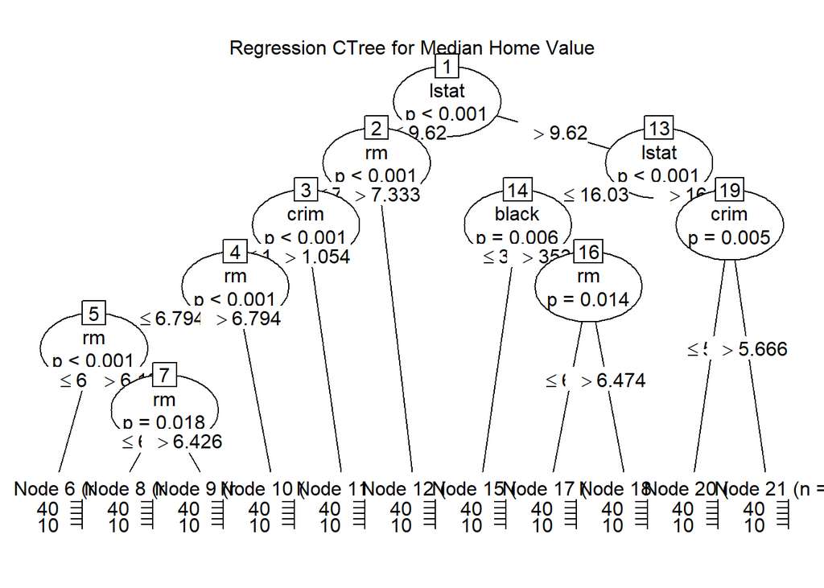

```r
# plot decision tree
plot(ctree.fit,
     main = "Regression CTree for Median Home Value")
```

```r
# Use model on test set, predict medv
ctree.pred = predict(ctree.fit, boston[-train,])

# R-squared evaluation of predictions
cor(ctree.pred,boston[-train,]$medv)^2
```

```
## [1] 0.7642602
```

```r
# The R-squared value of 0.76 is reasonable. The Conditional Inference approach ensures that the right-sized tree is grown without additional post-pruning or cross-validation. However, the depth of the tree is rather large, which makes interpretation more difficult than with less deep trees. In this case, pruning is undertaken for simplicity of plotting and interpretation, notwithstanding the primary role of pruning is to avoid overfitting the data.

# PRUNING

# Pruning can be easily done in this case by regrowing with a different control parameter.

# regrow the tree with smaller depth: maxdepth = 3
pruned.ctree.fit<- ctree(medv ~ .,
                         data = boston,
                         subset = train,
                         control = ctree_control(maxdepth = 3))

# examine pruned tree
print(pruned.ctree.fit)
```

```
##
## Model formula:
## medv ~ crim + zn + indus + chas + nox + rm + age + dis + rad +
##     tax + ptratio + black + lstat
##
## Fitted party:
## [1] root
## |   [2] lstat <= 9.62
## |   |   [3] rm <= 7.333
## |   |   |   [4] crim <= 1.05393: 26.374 (n = 98, err = 2455.7)
## |   |   |   [5] crim > 1.05393: 37.878 (n = 9, err = 1280.5)
## |   |   [6] rm > 7.333: 45.950 (n = 16, err = 297.1)
## |   [7] lstat > 9.62
## |   |   [8] lstat <= 16.03
## |   |   |   [9] black <= 353.04: 19.044 (n = 18, err = 209.3)
## |   |   |   [10] black > 353.04: 21.073 (n = 75, err = 561.7)
## |   |   [11] lstat > 16.03
## |   |   |   [12] crim <= 5.66637: 16.311 (n = 38, err = 406.4)
## |   |   |   [13] crim > 5.66637: 13.198 (n = 46, err = 636.3)
##
## Number of inner nodes:    6
## Number of terminal nodes: 7
```

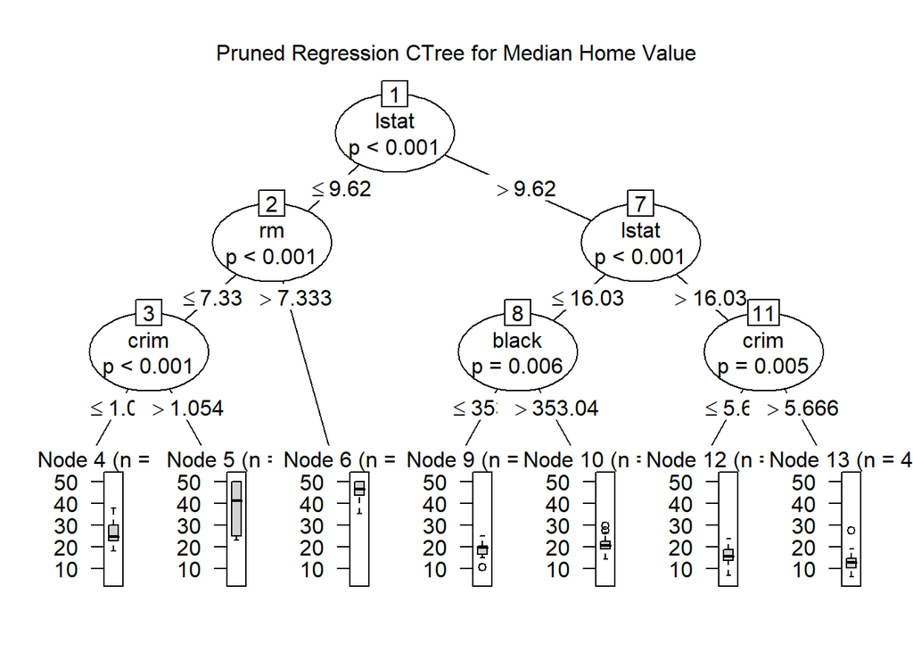

```r
# plot pruned tree
plot(pruned.ctree.fit,
     main = "Pruned Regression CTree for Median Home Value")
```

```r
# Use pruned model on test set, predict medv
pruned.ctree.pred = predict(pruned.ctree.fit, boston[-train,])

# R-squared evaluation of pruned model predictions
cor(pruned.ctree.pred,boston[-train,]$medv)^2
```

```
## [1] 0.7011987
```

```r
# The R-squared value has dropped to 0.70. The pruned tree provides an easier set of rules, at the expense of a relatively small decrease in prediction accuracy. Importantly, it also should be more generalisable to other data.
```

2. Attempt both a bagging and boosting method on a reasonable dataset of your choice. Explain the results.

```r
# BAGGING

data("Carseats")
carseats = Carseats

# convert quantitative variable Sales into a binary response
High = ifelse(carseats$Sales<=8, "No", "Yes")
carseats = data.frame(carseats, High)

# set seed to make results reproducible
set.seed(29)

# set up k-fold cross validation
cvcontrol <- trainControl(method = "repeatedcv",
                          number = 10,
                          allowParallel = TRUE)

# split data into train and test subset (250 and 150 respectively)
train = sample(1:nrow(carseats), 250)

# Fit train subset of data to model
bagg.carseats = train(High~.-Sales,
                      carseats,
                      subset = train,
                      method = "treebag",
                      trControl = cvcontrol)

bagg.carseats
```

```
## Bagged CART
##
## 400 samples
##  11 predictor
##   2 classes: 'No', 'Yes'
##
## No pre-processing
## Resampling: Cross-Validated (10 fold, repeated 1 times)
## Summary of sample sizes: 225, 225, 225, 225, 225, 225, ...
## Resampling results:
##
##   Accuracy   Kappa
##   0.7639103  0.5003862
```

```r
# Use model on test set, predict class labels
bagg.pred = predict(bagg.carseats,
                    carseats[-train,],
                    type= "raw")

# Evaluation of bagging predictions

# confusion matrix
confusionMatrix(carseats[-train,]$High,bagg.pred)
```

```
## Confusion Matrix and Statistics
##
##           Reference
## Prediction No Yes
##        No  78  10
##        Yes 20  42
##
##                Accuracy : 0.8
##                  95% CI : (0.727, 0.8608)
##     No Information Rate : 0.6533
##     P-Value [Acc > NIR] : 6.066e-05
##
##                   Kappa : 0.5775
##
##  Mcnemar's Test P-Value : 0.1003
##
##             Sensitivity : 0.7959
##             Specificity : 0.8077
##          Pos Pred Value : 0.8864
##          Neg Pred Value : 0.6774
##              Prevalence : 0.6533
##          Detection Rate : 0.5200
##    Detection Prevalence : 0.5867
##       Balanced Accuracy : 0.8018
##
##        'Positive' Class : No
##
```

```r
# accuracy 0.8

# ROC

# 4 steps

# obtain predicted probabilites for test data
bagg.probs=predict(bagg.carseats,
                   carseats[-train,],
                   type = "prob")

# calculate ROC
ROC.bagg <- roc(carseats[-train,]$High,bagg.probs[,"Yes"])
```

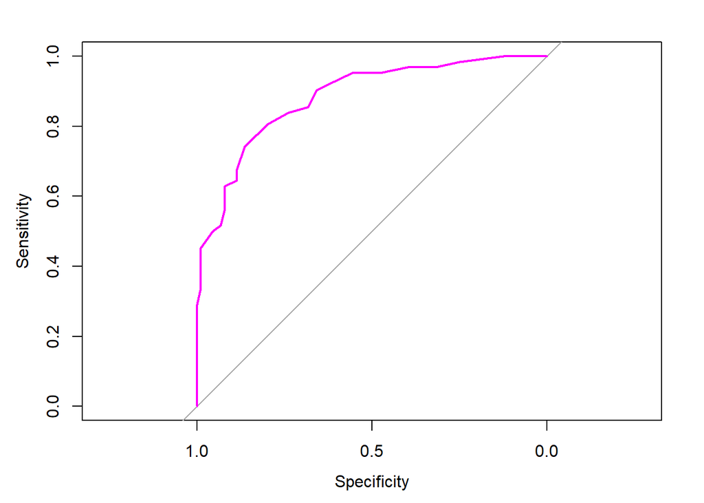

```r
# plot ROC
plot(ROC.bagg,col=c(6))
```

```r
# calculate AOC
auc(ROC.bagg)
```

```
## Area under the curve: 0.8823
```

```r
# 0.8823

# Evaluation shows reasonable model performance on test data, but room for improvement.

# BOOSTING

# set seed to make results reproducible
set.seed(29)

# Fit train subset of data to model
boost.carseats = train(High~.-Sales,
                       carseats,
                       subset = train,
                       method = "gbm", # gradient boosting
                       verbose = F,
                       trControl = cvcontrol)

boost.carseats
```

```
## Stochastic Gradient Boosting
##
## 400 samples
##  11 predictor
##   2 classes: 'No', 'Yes'
##
## No pre-processing
## Resampling: Cross-Validated (10 fold, repeated 1 times)
## Summary of sample sizes: 225, 225, 225, 225, 224, 225, ...
## Resampling results across tuning parameters:
##
##   interaction.depth  n.trees  Accuracy   Kappa
##   1                   50      0.7808974  0.5260940
##   1                  100      0.8206026  0.6237903
##   1                  150      0.8162821  0.6177463
##   2                   50      0.7725769  0.5113962
##   2                  100      0.8245897  0.6329985
##   2                  150      0.8124359  0.6065961
##   3                   50      0.8084359  0.5999136
##   3                  100      0.8282821  0.6467431
##   3                  150      0.8364487  0.6614884
##
## Tuning parameter 'shrinkage' was held constant at a value of 0.1
##
## Tuning parameter 'n.minobsinnode' was held constant at a value of 10
## Accuracy was used to select the optimal model using the largest value.
## The final values used for the model were n.trees = 150,
##  interaction.depth = 3, shrinkage = 0.1 and n.minobsinnode = 10.
```

```r
# Use model on test set, predict class labels
boost.pred = predict(boost.carseats,
                     carseats[-train,],
                     type = "raw")

# Evaluation of boosting predictions

# confusion matrix
confusionMatrix(carseats[-train,]$High,boost.pred)
```

```
## Confusion Matrix and Statistics
##
##           Reference
## Prediction No Yes
##        No  80   8
##        Yes 13  49
##
##                Accuracy : 0.86
##                  95% CI : (0.794, 0.9112)
##     No Information Rate : 0.62
##     P-Value [Acc > NIR] : 7.512e-11
##
##                   Kappa : 0.7078
##
##  Mcnemar's Test P-Value : 0.3827
##
##             Sensitivity : 0.8602
##             Specificity : 0.8596
##          Pos Pred Value : 0.9091
##          Neg Pred Value : 0.7903
##              Prevalence : 0.6200
##          Detection Rate : 0.5333
##    Detection Prevalence : 0.5867
##       Balanced Accuracy : 0.8599
##
##        'Positive' Class : No
##
```

```r
# accuracy 0.86

# ROC

# obtain predicted probabilites for test data
boost.probs=predict(boost.carseats,
                    carseats[-train,],
                    type = "prob")

# calculate ROC
ROC.boost <- roc(carseats[-train,]$High,boost.probs[,"Yes"])
```

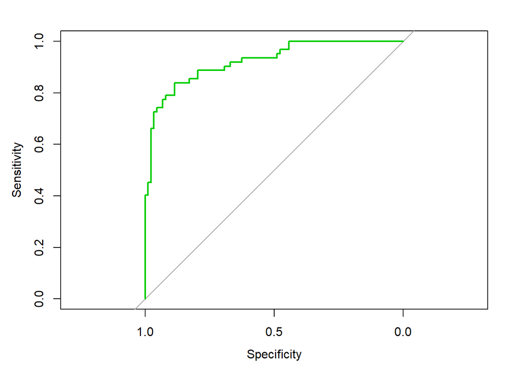

```r
# plot ROC
plot(ROC.boost,col=c(3))
```

```r
# calculate AOC
auc(ROC.boost)
```

```
## Area under the curve: 0.9225
```

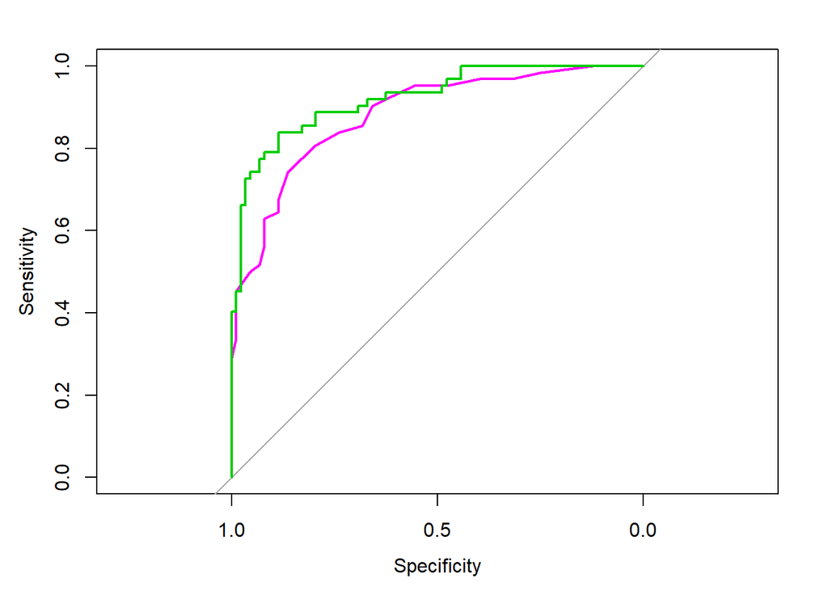

```r
# 0.9225

# Graphical comparison of bagging and boosting performances

plot(ROC.bagg,col=c(6)) # magenta-coloured curve
plot(ROC.boost, add = TRUE, col=c(3)) # green-coloured curve
```

```r
# For this dataset, gradient boosting has outperformed bagging.
```